# CA01 - Water Quality Metrics Analysis

MATH9102

Author

A00048448 Guilherme Prado

**Install all required R libraries**

```r
quiet_library <- function(pkg) {
  suppressMessages(suppressWarnings({
    if (!requireNamespace(pkg, quietly = TRUE)) {
      install.packages(pkg, quiet = TRUE)
    }
    library(pkg, character.only = TRUE)
  }))
}

quiet_library("tidyverse")    # Collection of R packages (dplyr, ggplot2, tidyr, etc.) for data wrangling, visualization, and analysis
quiet_library("pastecs")      # Tools for descriptive statistics, time series analysis, and data exploration (e.g., stat.desc)
quiet_library("psych")        # Descriptive statistics by group
quiet_library("FSA")          # Includes general tools for data analysis (e.g., nonparametric tests, bootstrapping)
quiet_library("semTools")     # Supplementary functions for Structural Equation Modeling (SEM), including model fit, reliability, and measurement invariance tests
quiet_library("VIM")          # Visualization and Imputation of Missing Values
quiet_library("naniar")       #(naniar short for NA + naniar) - Missing data wrangling plus Little's test
quiet_library("simputation")  # For imputing variables

quiet_library("sjstats")      # Provides convenient functions for effect sizes
quiet_library("gmodels")      # Includes 'CrossTable()' for contingency tables.

quiet_library("car")          # Includes Levene's test for homogeneity
quiet_library("effectsize")   # Includes calculations for effectsize
quiet_library("rstatix")      # Includes calculations for effectsize and Dunn's test

quiet_library("gtsummary")    # Formatting tables
quiet_library("flextable")    # Formatting tables
quiet_library("knitr")        # Used to print R objects inside functions
```

**Calculates Regular Summary Statistic**

```r
# Compute regular statistics and formats the output
format_summary_statistic <- function(stat_func, round_digits = 2) {
  return(
    as.data.frame(stat_func) %>%
        mutate(across(
          c(n, mean, sd, median, trimmed, mad, min, max, range, skew, kurtosis, se),
          ~ round(as.numeric(as.character(.)), round_digits)
        ))
  )
}
```

**Calculates Skewness and Kurtosis Scores**

```r
# Scores for Skewness and Kurtosis and FSA percents
skewness_kurtosis_score <- function(col) {
  if (!is.numeric(col)) {
      return("skewness_kurtosis_score: N/A")
  }
  # Generate standardized scores for skewness and kurtosis
  skew <- semTools::skew(col)
  kurt <- semTools::kurtosis(col)
  skew_z <- skew[1] / skew[2]
  kurt_z <- kurt[1] / kurt[2]

  # Calculate the percentage of standardized scores outside acceptable limits
  zcores <- abs(scale(col))

  perc_196 <- FSA::perc(as.numeric(zcores), 1.96, "gt")
  perc_329 <- FSA::perc(as.numeric(zcores), 3.29, "gt")

  score_result <- list(skew_z = skew_z, kurt_z = kurt_z, perc_gt_196 = perc_196, perc_gt_329 = perc_329)
  score_columns <- c("skew_z", "kurt_z", "perc_gt_196", "perc_gt_329")

  # Creates Table for visualization formatting purpose, creates data.frame from to manipulate, and finally convert the results to character and than to as numeric to enable optional rounding
  return (
    data.frame(
      table(score_result)
      )[score_columns]
        %>% mutate_at(score_columns, as.character)
          %>% mutate_at(score_columns, as.numeric)
  )
}
```

**Generates a Histogram**

```r
# Creates a histogram for a specified numeric column from a data frame using ggplot2. It is also overlays a red line representing a normal distribution curve, which is useful for visually assessing the normality of the data.
plot_hist_with_normal <- function(dtset, col, binwidth = 2, fill_low = "#DCDCDC", fill_high = "#7C7C7C") {
  if (!is.numeric(dtset[[col]])) {
      return("plot_hist_with_normal: N/A")
  }
  return(
      ggplot(dtset, aes(x = .data[[col]])) +
      labs(x = col) +
      geom_histogram(
          binwidth = binwidth,
          colour = "black",
          aes(y = after_stat(density), fill = after_stat(count))
      ) +
      scale_fill_gradient("Count", low = fill_low, high = fill_high) +
      stat_function(
          fun = dnorm,
          color = "red",
          args = list(
              mean = mean(dtset[[col]], na.rm = TRUE),
              sd = sd(dtset[[col]], na.rm = TRUE)
          )
      )
  )
}
```

**Generates a QQPlot**

```r
plot_qqplot <- function(dtset, col) {
  if (!is.numeric(dtset[[col]])) {
    return("plot_qqplot: N/A")
  }
  qqnorm(dtset[[col]])
  qqline(dtset[[col]], col = 2) # show a line on the plot
}
```

**Generates a Classification Group with Quantile**

```r
# Calculate a quantile-based breaks including min and max returns list of 2, one with the column and 2nd with the q_breaks ranges
create_classification_group <- function(dtset, col, n_break, lbl_break, show_break = FALSE) {
  # calculates the boundaries that divide the target-column distribution into n_break equal parts.
  q_breaks <- quantile(dtset[[col]], probs = seq(0, 1, length.out = n_break), na.rm = TRUE)
  # quantile(dtset[[col]], probs = seq(0, 1, length.out = break_length))

  if (show_break) {
    # knitr::kable transform a vector/matrix into presentable markdown
    print(knitr::kable(q_breaks, col=c("q_break", "value"), align = c("l", "r")))
  }

  # Return the target-column groups and the q_breaks
  return(
    list(
      data = cut(dtset[[col]], breaks = q_breaks, include.lowest = TRUE, labels = lbl_break),
      q_breaks = q_breaks,
      lbl_break = lbl_break
    )
  )
  # cut() then uses these boundaries to categorize each target-column into:
  # include.lowest = TRUE ensures the smallest target-column value is included in the first group.
}
```

**Formats Classification Groups into Range Values**

```r
# Formats the range of classification into labels, e.g., 1~2, 3~4
format_classification_group <- function(vect, digits = 2, sep = "~", unit = "", skip_last = FALSE, last_value = "+") {
  # Assuming 'vect' is available it rounds the break points
  rounded_breaks <- round(vect, digits = digits)

  # Initialize an empty vector to store the range strings
  range_labels <- c()

  # Loop from the first to the second-to-last break
  for (i in 1:(length(rounded_breaks) - 1)) {
    # Define the start of the range
    # For the first item, use its value. For others, use the previous break's value + 1.
    start_val <- ifelse(i == 1, rounded_breaks[i], rounded_breaks[i] + 1)

    # Define the end of the range
    end_val <- rounded_breaks[i + 1]

    # Combine them into a "start-end" string and add to the vector
    range_labels[i] <- ifelse(
      skip_last & i == length(rounded_breaks) - 1,
        paste0(start_val, last_value, unit),
        paste0(start_val, sep, end_val, unit)
      )
  }
  return(range_labels)
}
```

**Read and Normalize dataset columns**

```r
data_location <- file.path("D:\\code\\TUDublin\\main\\MATH9102\\ca1-sub-w9\\data")
file_path <- file.path(data_location, "Water Quality.csv")
water_quality <- read.csv(file_path, header=TRUE)

# Setting the column names to be that used in the dataset but in lowercase to make life a bit easier
colnames(water_quality) <- tolower(colnames(water_quality))
```

**Creates Conductivity Groups**

```r
# The goal of this code is to divide water conductivity into 5 classification groups (optimal, acceptable, marginal, concerning, critical) based on the distribution of the values in the dataset to cover the assignment requirements.

# Divide data into 5 equal groups (quintiles) using 6 breakpoints
n_break <- 6

# Keeping the result for further Data assessment
conductivity_class_result <- create_classification_group(
  dtset = water_quality,
  col = "conductivity",
  n_break = n_break,
  lbl_break = c("optimal", "acceptable", "marginal", "concerning", "critical"),
  show_break = FALSE
)

# Set the result into the new column
water_quality$conductivity_group <- conductivity_class_result$data
```

**Parse Potability**

```r
# Coping the potability field to portability_val and running a mutation with case_when to overwrite potability values.

# Keeping the original value of potability
water_quality$potability_val <- water_quality$potability

# Mutate the potability value to descriptive value to work with data exploration algorithms
water_quality <- water_quality %>%
  mutate(potability = case_when(
    potability < 1 ~ "non-potable",
    TRUE ~ "potable"
  ))
```

# 1. Introduction

This analysis uses a water-quality dataset comprising measurements from multiple water bodies[^1] aiming to investigate the relationships between **potability**, **conductivity group** and **turbidity** to evaluate their predictive on **organic carbon** concentrations.

| Analysis Focus | Null Hypothesis (H₀) | Alternative Hypothesis (H₁) |
| --- | --- | --- |
| **Turbidity and Organic Carbon** | A water’s level of turbidity is **not related** to its organic carbon level. | A water’s level of turbidity is **related** to its organic carbon level. |
| **Potability and Organic Carbon** | The water potability provided is **not related** water’s organic carbon level. | The water potability provided is **related** water’s organic carbon level. |
| **Conductivity Group and Potability** | A water’s conductivity group and the potability provided are **independent** (unrelated). | A water’s conductivity group and the potability provided are **associated**. |
| **Conductivity Group and Organic Carbon** | Water’s organic carbon level does **not differ** across conductivity groups. | Water’s organic carbon level **differs** across conductivity groups. |

Table 1: Hypotheses for Planned Analysis.

In the remainder of this report, Section 2 describes the dataset used for the analysis, including variable descriptions and data preparation steps. Section 3 outlines the analytical approach, detailing the statistical methods and rationale for their selection. Section 4 presents the results of the analyses, organised by hypothesis. Section 5 discusses the main findings in the context of the analysis aims, highlighting their implications and limitations. Finally, Section 6 provides a concise conclusion, summarising the key insights and potential directions for future research. References and any supplementary materials are provided in Section 7 and the Appendix 8, respectively.

# 2. Dataset

The water-quality dataset consist of measurements from 3276 water bodies. The concepts of interest are outlined in Table 2. Each associated variable was examined to determine whether the level of missing data could introduce bias. No missing data were identified (see appendix section, Note 1).

A new variable was created based on water conductivity, categorizing it into five groups. In this classification, 20.024% of the water conductivity were identified as optimal (181-354 μS/cm), 19.994% as acceptable (355-400 μS/cm), 19.994% as marginal (401-444 μS/cm), 19.994% as concerning (445-496 μS/cm), and 19.994% as critical (497+ μS/cm). Refer to appendix section Table 9 (a), Table 9 (b) and Table 9 (c) for more details.

[output not shown]

Table 2: Concepts of Interest for Planned Analysis.

Before statistical tests were conducted, the data representing the relevant concepts was inspected to determine the correct test to be used.

Water’s level of turbidity were assessed for normality. Visual inspection of the histogram and QQ-Plot (see Figure 1 and Figure 2) suggested some potential deviations due to skewness and kurtosis. The standardized score for skewness (-0.18) and the standardised score for kurtosis (-0.73) can considered acceptable using the criteria proposed by Curran, West and Finch (1996). Inspection of the standardised scores showed that 95% of fall within the bounds of +/-1.96 and 99% fall within the bounds of +/- 3.29. Thus, using the guidance of Field, Miles and Field (2012), there are insufficient outliers to be considered problematic. Therefore the data for turbidity can be considered to approximate a normal distribution (m=3.97, sd=0.78, n=3276). See appendix section Table 11 for more details.

**Creates Turbidity Histogram**

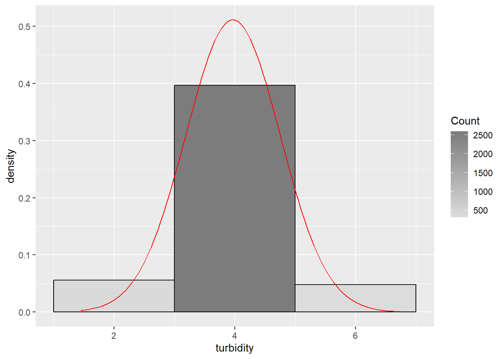

Figure 1: Histogram of Turbidity

```r
plot_hist_with_normal(dtset = water_quality, col = "turbidity")
```

**Creates Turbidity QQPlot**

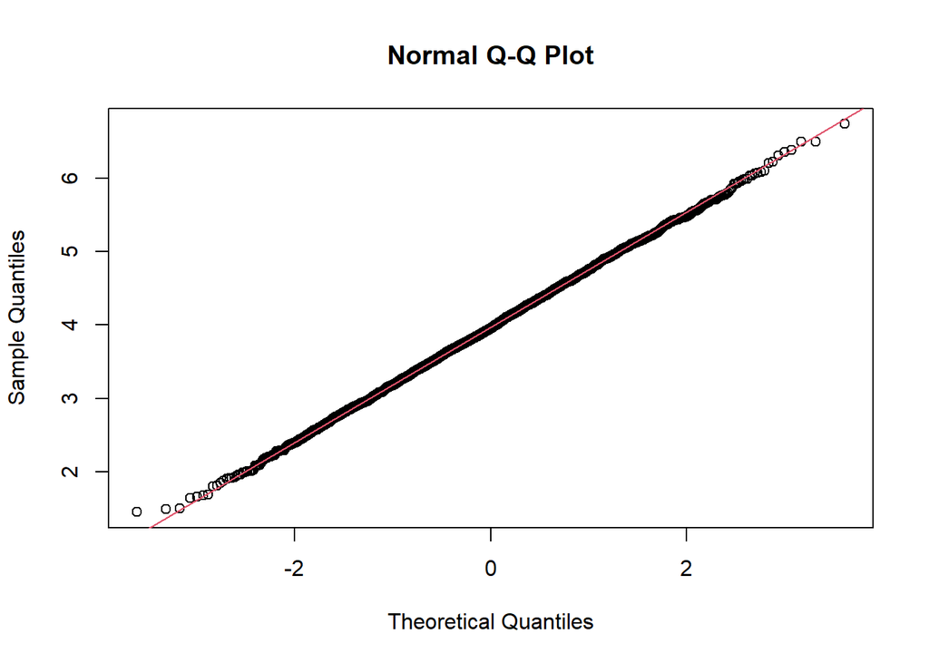

Figure 2: QQ-Plot of Turbidity

```r
plot_qqplot(dtset = water_quality, col = "turbidity")
```

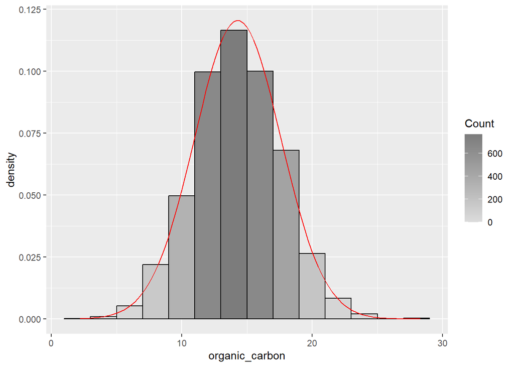

Figure 3: Histogram of Organic Carbon

```r
plot_hist_with_normal(dtset = water_quality, col = "organic_carbon")
```

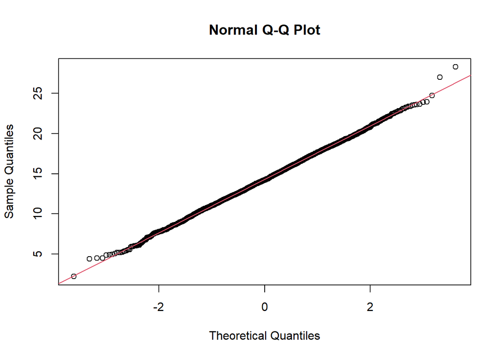

Figure 4: QQPlot of Organic Carbon

```r
plot_qqplot(dtset = water_quality, col = "organic_carbon")
```

The number of water bodies records in each conductivity group for each potability group (non-potable and potable) Table 3.

```r
# Create and style the summary table
table3 <- water_quality %>%
  select(conductivity_group, potability) %>%
  tbl_summary(
    by = potability,                       # Compare across potability
    statistic = all_categorical() ~ "{n}", # Show counts only
    missing = "no",
    label = list(conductivity_group ~ "**Conductivity Group**")   # Bold label directly here
  )

# Convert to flextable for nice output
#as_flex_table(table3)
# skip the flextable to render as markdown
table3
```

| **Characteristic** | **non-potable** N = 1,998<sup>1</sup> | **potable** N = 1,278<sup>1</sup> |
| --- | --- | --- |
| **Conductivity Group** |  |  |
| optimal | 381 | 275 |
| acceptable | 414 | 241 |
| marginal | 402 | 253 |
| concerning | 413 | 242 |
| critical | 388 | 267 |

<sup>1</sup> n

Table 3: Cross Tabulation of Conductivity Group and Potability

# 3. Analysis Approach

An alpha level of .05 was adopted as the threshold for statistical significance, in line with conventional standards in water quality dataset. Results with p values less than .05 are considered statistically significant. To assess the practical significance of findings, effect sizes will be reported alongside p values.

For parametric difference tests, eta squared (η²) will be used as the measure of effect size, interpreted according to Cohen’s (1988) conventions, where values of approximately .01, .06, and .14 represent small, medium, and large effects, respectively.

For correlational analyses, Pearson’s r will be reported, with effect sizes interpreted using benchmarks of .10, .30, and .50 for small, medium, and large associations, respectively.

For associations between nominal variables, a Chi-Square test will be conducted, and (or Cramér’s V) will be reported as the measure of effect size, using benchmarks of .05, .15, and .25 to indicate small, medium, and large associations.

Reporting both statistical significance and effect size provides a more comprehensive understanding of the magnitude and practical importance of the observed effects.

# 4. Results

## 4.1 Turbidity and Organic Carbon

| Hypothesis | Description |
| --- | --- |
| Null (H₀) | A water’s level of turbidity is **not related** to its organic carbon level. |
| Alternative (H₁) | A water’s level of turbidity is **related** to its organic carbon level. |

Table 4: Turbidity and Organic Carbon Hypothesis.

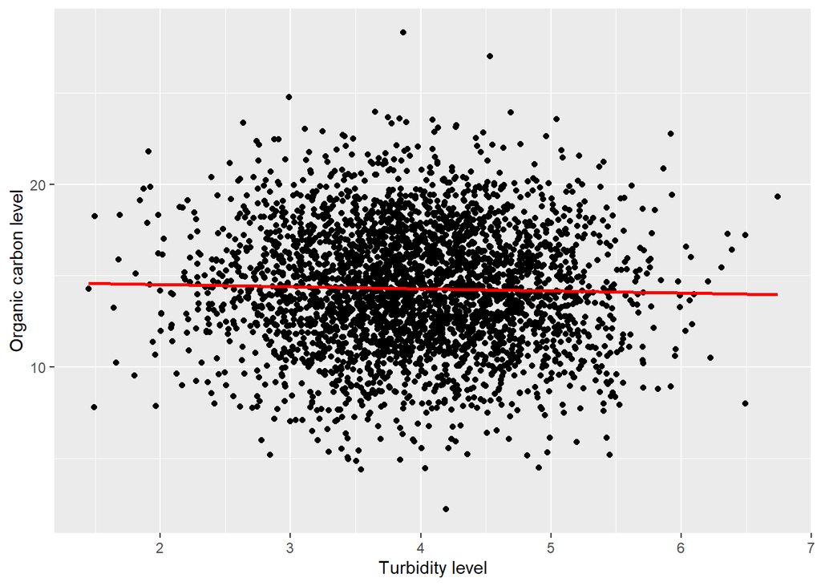

Figure 5: Scatterplot Turbidity and Organic Carbon

```r
#aes(x,y) - turbidity is the independent and Organic Carbon is the outcome
scatter <- ggplot(water_quality, aes(x = turbidity, y = organic_carbon)) +
  labs(
    x = "Turbidity level",
    y = "Organic carbon level"
  )

# Add regression line
scatter + geom_point() +
  geom_smooth(method = "lm", colour = "red", se = FALSE)
```

## 4.2 Potability and Organic Carbon

| Hypothesis | Description |
| --- | --- |
| Null (H₀) | The water potability provided is **not related** water’s organic carbon level. |
| Alternative (H₁) | The water potability provided is **related** water’s organic carbon level. |

Table 5: Potability and Organic Carbon

## 4.3 Conductivity Group and Potability

| Hypothesis | Description |
| --- | --- |
| Null (H₀) | A water’s conductivity group and the potability provided are **independent** (unrelated). |
| Alternative (H₁) | A water’s conductivity group and the potability provided are **associated**. |

Table 6: Conductivity Group and Potability

## 4.4 Conductivity Group and Organic Carbon

| Hypothesis | Description |
| --- | --- |
| Null (H₀) | Water’s organic carbon level does **not differ** across conductivity groups. |
| Alternative (H₁) | Water’s organic carbon level **differs** across conductivity groups. |

Table 7: Conductivity Group and Organic Carbon

A one-way between-groups analysis of variance (ANOVA) was conducted to examine the impact of conductivity group on oraganic carbon. Water bodies were divided into five groups based on conductivity range: optimal (354 μS/cm or lower), acceptable (355-400 μS/cm), marginal (401-444 μS/cm), concerning (445-496 μS/cm) and critical (497 μS/cm and above) (see appendix section, Table 9 (c) for details). There was no statistically significant difference in oraganic carbon between the five conductivity groups, F(4, 3271)=1.55, p=0.19. The effect size, calculated using eta squared, was η²=0.002, indicating a very small effect (precise values at appendix section, Note 6).

The Table 8 lists the mean for the five conductivity groups:

```r
# Generate the Descriptive Statistics for Organic Carbon by Conductivity Group and format the output
knitr::kable(
  format_summary_statistic(
    psych::describeBy(water_quality$organic_carbon, water_quality$conductivity_group, mat=TRUE),
    round_digits = 2
    )[c("group1", "mean", "sd", "n")], # select only columns to display
  col = c("Conductivity Group", "Mean", "SD", "N") # the the labels to each column for the markdown table
)
```

|  | Conductivity Group | Mean | SD | N |
| --- | --- | --- | --- | --- |
| X11 | optimal | 14.23 | 3.30 | 656 |
| X12 | acceptable | 14.31 | 3.34 | 655 |
| X13 | marginal | 14.23 | 3.32 | 655 |
| X14 | concerning | 14.11 | 3.28 | 655 |
| X15 | critical | 14.54 | 3.30 | 655 |

Table 8: Descriptive Statistics for Organic Carbon by Conductivity Group

Therefore, there is no evidence to reject the null hypothesis. Oraganic carbon did not differ significantly based on conductivity group, suggesting that water bodies of varying condictivity performed similarly regardless of the water’s conductivity levels.

# 5. Discussion

The aim of this analysis was to explore relationships between water quality metrics—specifically turbidity, potability, conductivity groups, and organic carbon concentrations—to assess their utility in predicting water quality outcomes. Across all four analyses, no statistically significant associations or differences were observed, suggesting these variables do not meaningfully predict organic carbon levels within this sample.

The absence of a significant correlation between turbidity and organic carbon indicates that suspended solids do not reliably predict organic matter concentrations in these water bodies. This finding may reflect the complexity of organic carbon sources, which include both natural decomposition and synthetic inputs that may not consistently correlate with particulate matter.

Similarly, organic carbon levels did not differ significantly between potable and non-potable water, suggesting that potability classifications in this dataset were determined by factors other than total organic carbon. This may indicate that other contaminants or regulatory thresholds played a more decisive role in potability assessment.

The Chi-square and Cramér’s V analysis confirmed that conductivity groups and potability were independent, indicating no selection bias or systematic relationship between ionic concentration and drinkability. The ANOVA results further revealed that organic carbon did not vary significantly across conductivity groups, despite conductivity being commonly associated with dissolved solids and potential contamination.

Collectively, these findings suggest that within this dataset, conventional water quality indicators were not strong predictors of organic carbon or potability. It is possible that other types of measurament metrics—such as specific ion composition, pH, microbial content, or geographic source characteristics—may better explain water quality outcomes.

Limitations include the dataset’s representativeness, as sampling methods and geographic distribution were not detailed. Additionally, the binary potability classification may oversimplify water quality assessment, potentially masking subtle but meaningful variations in contamination levels.

# 6. Conclusion

This analysis found no evidence of significant relationships between organic carbon concentrations and the examined water quality metrics. Turbidity, potability, and conductivity groupings all failed to demonstrate meaningful associations with organic carbon levels, with effect sizes indicating negligible practical importance across all tests.

The homogeneity of variance assumptions were met for parametric tests, and data distributions approximated normality according to established criteria, supporting the validity of the analytical approach. These findings suggest that predicting or explaining organic carbon variability requires consideration of factors beyond the basic physical and chemical measurements examined here.

Future research should investigate temporal patterns, geographical variations, and additional water quality parameters such as dissolved oxygen, pH stability, and specific pollution sources. The high mean organic carbon level (14.28 mg/L) compared to EPA recommendations indicates that these water bodies would benefit from enhanced monitoring and treatment protocols. Understanding the drivers of organic carbon accumulation remains essential for effective water quality management and treatment planning.

# 7. References

Cohen, J. (1988). Statistical power analysis for the behavioral sciences (2nd ed.). Hillside, NJ: Lawrence Erlbaum Associates.

Curran, Patrick J., Stephen G. West, and John F. Finch. (1996). “The robustness of test statistics to nonnormality and specification error in confirmatory factor analysis.”

Field, A., Field Z. & Miles J.(2012). Discovering statistics using IBM SPSS statistics. Sage publications limited.

Water Quality. https://www.kaggle.com/datasets/adityakadiwal/water-potability. Accessed 20 Set. 2025.

# Appendix

## General Descriptives

### Conductivity Group Proportions:

```r
# Show the record frequency for each conductivity group
knitr::kable(table(water_quality$conductivity_group), col = c("Group", "Freq"))
# Show the percentage frequency for each conductivity group
knitr::kable(proportions(table(water_quality$conductivity_group)), col = c("Group", "Freq"))
# Show the range for each conductivity group
knitr::kable(data.frame(
  Group = conductivity_class_result$lbl_break,
  Range = format_classification_group(
    vect = conductivity_class_result$q_breaks,
    digits = 0,
    sep = "-",
    unit = "",
    skip_last = TRUE,
    last_value = "+")
), col = c("Group", "Range"))
```

| Group | Freq |
| --- | --- |
| optimal | 656 |
| acceptable | 655 |
| marginal | 655 |
| concerning | 655 |
| critical | 655 |

(a) Conductivity Group (Records)

| Group | Freq |
| --- | --- |
| optimal | 0.2002442 |
| acceptable | 0.1999389 |
| marginal | 0.1999389 |
| concerning | 0.1999389 |
| critical | 0.1999389 |

(b) Conductivity Group (Percents)

| Group | Range |
| --- | --- |
| optimal | 181-354 |
| acceptable | 355-400 |
| marginal | 401-444 |
| concerning | 445-496 |
| critical | 497+ |

(c) Conductivity Group (Range)

Table 9: Conductivity Group Proportions

### Potability Proportions:

```r
# Show the record frequency for each potability binary value
knitr::kable(table(water_quality$potability), col = c("Group", "Freq"))
# Show the percentage frequency for each potability binary value
knitr::kable(proportions(table(water_quality$potability)), col = c("Group", "Freq"))
```

| Group | Freq |
| --- | --- |
| non-potable | 1998 |
| potable | 1278 |

(a) Potability (Records)

| Group | Freq |
| --- | --- |
| non-potable | 0.6098901 |
| potable | 0.3901099 |

(b) Potability (Percents)

Table 10: Potability Proportions

### Missing Data Check

**Note 1**

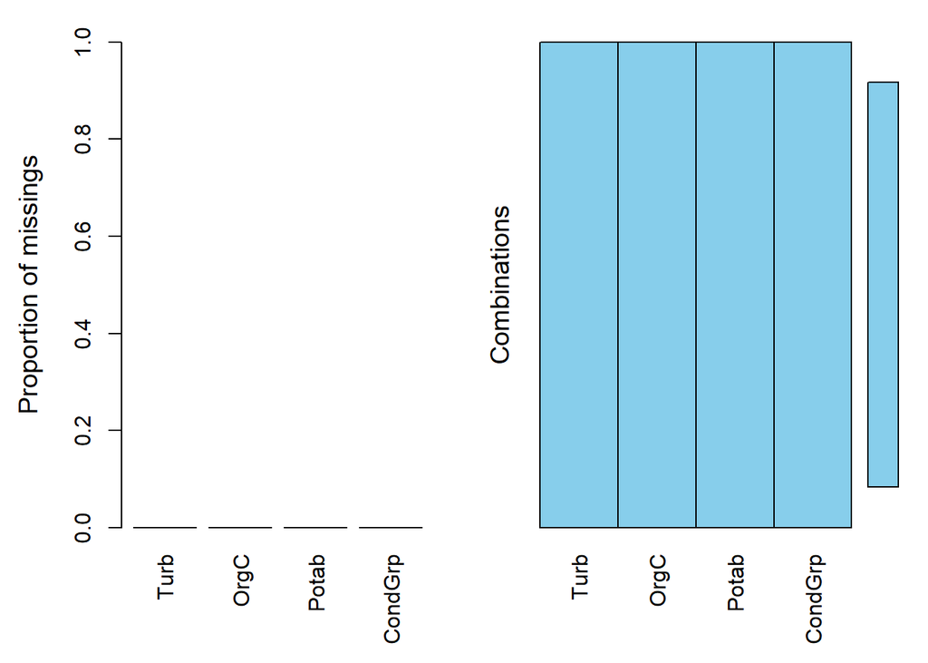

```
 Variables sorted by number of missings:
 Variable Count
     Turb     0
     OrgC     0
    Potab     0
  CondGrp     0
```

```
  Combinations Count Percent
1      0:0:0:0  3276     100
```

```r
varsint <- c("turbidity", "organic_carbon", "potability", "conductivity_group")
esub <- water_quality[varsint]

#Adjust the margins so that we can display the labels
par(mar = c(10, 4, 4, 2))  # more space at bottom

# rename columns to human-friendly labels - we are restricted with the length we can use
colnames(esub) <- c("Turb", "OrgC", "Potab", "CondGrp")

# run VIM::aggr
summary(VIM::aggr(esub, sortVar = TRUE, combined = FALSE))$combinations
```

```r
# Include Little's MCAR if you have data missing (no data missing)
# mcar_result <- naniar::mcar_test(data.frame(esub))
# mcar_result
```

## Normality Assessment (Turbidity and Organic Carbon)

### Turbidity

```r
# Uses psych::describe to compute regular statistics and formats the output using table, data.frame, and mutate functions.
knitr::kable(
  format_summary_statistic(psych::describe(water_quality$turbidity),
  round_digits = 2
))
# Generate standardized scores for skewness and kurtosis
knitr::kable(round(skewness_kurtosis_score(water_quality$turbidity), digits = 3))
# Below we are reporting the normality assessment - embedding code within a paragraph to get the statistics generated (you can just write it out)
```

|  | vars | n | mean | sd | median | trimmed | mad | min | max | range | skew | kurtosis | se |
| --- | --- | --- | --- | --- | --- | --- | --- | --- | --- | --- | --- | --- | --- |
| X1 | 1 | 3276 | 3.97 | 0.78 | 3.96 | 3.97 | 0.79 | 1.45 | 6.74 | 5.29 | -0.01 | -0.07 | 0.01 |

(a) Regular summary statistics

| skew_z | kurt_z | perc_gt_196 | perc_gt_329 |
| --- | --- | --- | --- |
| -0.183 | -0.734 | 4.731 | 0.031 |

(b) Standardized scores for skewness and kurtosis

Table 11: Normality Assessment (turbidity)

### Organic Carbon

```r
# Uses psych::describe to compute regular statistics and formats the output using table, data.frame, and mutate functions.
knitr::kable(
  format_summary_statistic(psych::describe(water_quality$organic_carbon),
  round_digits = 2
))
# Generate standardized scores for skewness and kurtosis
knitr::kable(round(skewness_kurtosis_score(water_quality$organic_carbon), digits = 3))
```

|  | vars | n | mean | sd | median | trimmed | mad | min | max | range | skew | kurtosis | se |
| --- | --- | --- | --- | --- | --- | --- | --- | --- | --- | --- | --- | --- | --- |
| X1 | 1 | 3276 | 14.28 | 3.31 | 14.22 | 14.29 | 3.31 | 2.2 | 28.3 | 26.1 | 0.03 | 0.04 | 0.06 |

(a) Regular summary statistics

| skew_z | kurt_z | perc_gt_196 | perc_gt_329 |
| --- | --- | --- | --- |
| 0.597 | 0.519 | 4.853 | 0.092 |

(b) Standardized scores for skewness and kurtosis

Table 12: Normality Assessment (organic carbon)

## Correlation Test (Turbidity and Organic Carbon)

**Note 2**

```r
# Pearson Correlation - this is the correct test for this data
stats::cor.test(water_quality$turbidity, water_quality$organic_carbon, method='pearson')
```

```
    Pearson's product-moment correlation

data:  water_quality$turbidity and water_quality$organic_carbon
t = -1.5631, df = 3274, p-value = 0.1181
alternative hypothesis: true correlation is not equal to 0
95 percent confidence interval:
 -0.061496238  0.006944016
sample estimates:
        cor
-0.02730811
```

## T-Test (Organic Carbon by Potability)

**Note 3**

```r
# Conduct Levene's test for homogeneity of variance in library car - the null hypothesis is that variances in groups are equal so to assume homogeneity we would expect probability to not be statistically significant.
car::leveneTest(organic_carbon ~ potability, data=water_quality)
```

```
Levene's Test for Homogeneity of Variance (center = median)
        Df F value Pr(>F)
group    1  0.8274 0.3631
      3274
```

**Note 4**

```r
# Conduct the t-test from package stats - basic r package. Prefixing it to make sure that is the one used rather than t-test from another package.

# In this case we can use the var.equal = TRUE option to specify equal variances and a pooled variance estimate
stats::t.test(organic_carbon ~ potability, var.equal=TRUE,data=water_quality)
```

```
    Two Sample t-test

data:  organic_carbon by potability
t = 1.7174, df = 3274, p-value = 0.086
alternative hypothesis: true difference in means between group non-potable and group potable is not equal to 0
95 percent confidence interval:
 -0.02881755  0.43570307
sample estimates:
mean in group non-potable     mean in group potable
                 14.36434                  14.16089
```

```r
#No statistically significant difference was found

res <- stats::t.test(organic_carbon ~ potability, var.equal=TRUE,data=water_quality)
#Calculate Cohen's d
#artithmetically
effcd <- round((2*res$statistic)/sqrt(res$parameter),2)
effcd
```

```
   t
0.06
```

```r
#Alternate approach -Using function from effectsize package to convert t to Cohen's d
effectsize::t_to_d(t = res$statistic, res$parameter)
```

```
d    |        95% CI
--------------------
0.06 | [-0.01, 0.13]
```

```r
#Calculate eta squared
effes <- round((res$statistic*res$statistic)/((res$statistic*res$statistic)+(res$parameter)), 3)
effes
```

```
    t
0.001
```

[figure not shown]

Figure 6: Histogram Organic Carbon by Potability

```r
# Create a separate histogram showing the distribution for the two (potentially) separate populations (the groups)
# Create the plot with both histogram and density plot
ggplot(water_quality, aes(x=organic_carbon, color=potability, fill=potability))  +
  labs(x="Organic Carbon Levels") +
  # Histogram with alpha for transparency
  geom_histogram(aes(y = after_stat(density)), position="identity", alpha=0.5, binwidth=0.5, color="black") +
  # Density plot with transparency for overlapping curves
  geom_density(alpha=0.4) +
  # Customize the color and fill scales
  scale_color_manual(values=c("blue", "red"), labels=c("potable", "non-potable")) +
  scale_fill_manual(values=c("lightblue", "lightcoral"), labels=c("potable", "non-potable"))
```

```r
# Pr(>F) is your probability - in this case it is not statistically significant so we can assume homogeneity and wrapps into a function to format as markdown table
knitr::kable(format_summary_statistic(
  psych::describeBy(water_quality$organic_carbon, water_quality$potability, mat=TRUE),
  round_digits = 2
))
```

|  | item | group1 | vars | n | mean | sd | median | trimmed | mad | min | max | range | skew | kurtosis | se |
| --- | --- | --- | --- | --- | --- | --- | --- | --- | --- | --- | --- | --- | --- | --- | --- |
| X11 | 1 | non-potable | 1 | 1998 | 14.36 | 3.33 | 14.29 | 14.36 | 3.39 | 4.37 | 28.3 | 23.93 | 0.07 | 0.08 | 0.07 |
| X12 | 2 | potable | 1 | 1278 | 14.16 | 3.26 | 14.16 | 14.18 | 3.21 | 2.20 | 23.6 | 21.40 | -0.05 | -0.06 | 0.09 |

Table 13: Descriptive statistics (Organic Carbon by Potability)

## Chi-square (Conductivity Group and Potability)

**Note 5**

```r
# Note: for this approach there must be the same number of values for both variables so missing data is important.

# Remove rows where either variable is NA
water_quality_c <- water_quality%>%
  filter(!is.na(conductivity_group) & !is.na(potability))

# Now run CrossTable requesting both Fisher and Chi Square so we have full information
# We request the format in SPSS to make it easier to interpret.
gmodels::CrossTable(
  water_quality_c$conductivity_group,
  water_quality_c$potability,
  fisher = TRUE,
  chisq = TRUE,
  expected = TRUE,
  sresid = TRUE,
  format = "SPSS"
)
```

```
   Cell Contents
|-------------------------|
|                   Count |
|         Expected Values |
| Chi-square contribution |
|             Row Percent |
|          Column Percent |
|           Total Percent |
|            Std Residual |
|-------------------------|

Total Observations in Table:  3276

                                   | water_quality_c$potability
water_quality_c$conductivity_group | non-potable  |     potable  |   Row Total |
-----------------------------------|-------------|-------------|-------------|
                           optimal |        381  |        275  |        656  |
                                   |    400.088  |    255.912  |             |
                                   |      0.911  |      1.424  |             |
                                   |     58.079% |     41.921% |     20.024% |
                                   |     19.069% |     21.518% |             |
                                   |     11.630% |      8.394% |             |
                                   |     -0.954  |      1.193  |             |
-----------------------------------|-------------|-------------|-------------|
                        acceptable |        414  |        241  |        655  |
                                   |    399.478  |    255.522  |             |
                                   |      0.528  |      0.825  |             |
                                   |     63.206% |     36.794% |     19.994% |
                                   |     20.721% |     18.858% |             |
                                   |     12.637% |      7.357% |             |
                                   |      0.727  |     -0.908  |             |
-----------------------------------|-------------|-------------|-------------|
                          marginal |        402  |        253  |        655  |
                                   |    399.478  |    255.522  |             |
                                   |      0.016  |      0.025  |             |
                                   |     61.374% |     38.626% |     19.994% |
                                   |     20.120% |     19.797% |             |
                                   |     12.271% |      7.723% |             |
                                   |      0.126  |     -0.158  |             |
-----------------------------------|-------------|-------------|-------------|
```

[output cut: 22 more lines]

```


Pearson's Chi-squared test
------------------------------------------------------------
Chi^2 =  5.747101     d.f. =  4     p =  0.2188478



Fisher's Exact Test for Count Data
------------------------------------------------------------
Alternative hypothesis: two.sided
p =  0.2198229


       Minimum expected frequency: 255.522
```

```r
# Alternate approach: Create your own contingency table
mytable <- xtabs(~conductivity_group+potability, data=water_quality)
# You can use the chisq.test function in the stats package to do the test set the flag correct=TRUE to get Yates correction needed for 2x2 table
ctest <- stats::chisq.test(mytable, correct=TRUE)#chi square test
#Calculate effect sizes
sjstats::cramer(mytable)
```

```
[1] 0.04188442
```

## ANOVA (Organic Carbon by Conductiviy Group)

**Note 6**

```r
# Conduct Bartlett's test for homogeneity of variance  - the null hypothesis is that variances in groups are equal so to assume homogeneity we would expect probability to not be statistically significant.
stats::bartlett.test(organic_carbon ~ conductivity_group, data = water_quality)
```

```
    Bartlett test of homogeneity of variances

data:  organic_carbon by conductivity_group
Bartlett's K-squared = 0.27642, df = 4, p-value = 0.9913
```

```r
# p value is > 0.05 so the result is not statistically significant so we can assume homogeneity

# Conduct ANOVA using the one-way ANOVA from the stats package

# Compute the analysis of variance using the oneway.test from the stats package- we set VAR.equal to be true because we have homogeneity
res <- stats::oneway.test(organic_carbon ~ as.factor(conductivity_group), data = water_quality, var.equal = TRUE)
# Summary of the analysis
res
```

```
    One-way analysis of means

data:  organic_carbon and as.factor(conductivity_group)
F = 1.545, num df = 4, denom df = 3271, p-value = 0.1864
```

```r
# We would use Tukey for post-hoc testing - not needed here. Use Games Howell if Levene is significant.
# rstatix::tukey_hsd(water_quality, organic_carbon ~ conductivity_group)

# Compute our Eta squared
effectsize::effectsize(res)
```

```
Eta2     |       95% CI
-----------------------
1.89e-03 | [0.00, 1.00]

- One-sided CIs: upper bound fixed at [1.00].
```

```r
# Get descriptive statistics by group - output as a matrix and wrapps into a function to format as markdown table
knitr::kable(format_summary_statistic(
  psych::describeBy(water_quality$organic_carbon, water_quality$conductivity_group, mat=TRUE),
  round_digits = 2
))
```

|  | item | group1 | vars | n | mean | sd | median | trimmed | mad | min | max | range | skew | kurtosis | se |
| --- | --- | --- | --- | --- | --- | --- | --- | --- | --- | --- | --- | --- | --- | --- | --- |
| X11 | 1 | optimal | 1 | 656 | 14.23 | 3.30 | 14.10 | 14.23 | 3.42 | 4.47 | 23.92 | 19.44 | 0.06 | -0.16 | 0.13 |
| X12 | 2 | acceptable | 1 | 655 | 14.31 | 3.34 | 14.25 | 14.32 | 3.38 | 2.20 | 28.30 | 26.10 | 0.02 | 0.52 | 0.13 |
| X13 | 3 | marginal | 1 | 655 | 14.23 | 3.32 | 14.09 | 14.20 | 3.27 | 4.97 | 23.51 | 18.55 | 0.10 | -0.15 | 0.13 |
| X14 | 4 | concerning | 1 | 655 | 14.11 | 3.28 | 14.11 | 14.15 | 3.13 | 4.37 | 22.76 | 18.39 | -0.12 | 0.01 | 0.13 |
| X15 | 5 | critical | 1 | 655 | 14.54 | 3.30 | 14.48 | 14.53 | 3.30 | 5.36 | 24.76 | 19.39 | 0.06 | -0.11 | 0.13 |

Table 14: Descriptive statistics (Organic Carbon by Conductiviy Group)

## Footnotes

[^1]: “Water bodies” denotes significant accumulations of water on the Earth’s surface, such as oceans, lakes, rivers, and seas.
[^2]: Total Organic Carbon
[^3]: United States of America Environmental Protection Agency
[^4]: Milligram per Litre
[^5]: World Health Organization
[^6]: Nephelometric Turbidity Unit
[^7]: Microsiemens per Centimeter